# notebook_exam_statistical_data_analysis

# Introduction

*Note: in the top right corner there’s the switch to pass from light to dark mode and vice versa*  
The aim of this notebook is to explain the scripts found in the folder `02_new_scripts/`.  
Scripts that would normally ask the user for input (a threshold, a fraction) are called here with those values passed directly as arguments, so every chunk in this notebook runs on its own, with no manual input required.  
Scripts can be divided into three categories:

- **base functions**: small scripts that generate simple functions (a wise man once said: “if you have to do it more than once, instead write a script!”).  
  The base functions are:
  - `datasummary.R`
  - `filt_data.R`
  - `pseudocount.R`
  - `generate_matrix_factors.R`
  - `pielou_ind.R`
- **Orchestrators**: these scripts are more complex than the base functions and combine them to perform more elaborate tasks. The orchestrators are:
  - `clr_pearson.R`
  - `NorTa_simulation.R`
  - `data_sim_ph_driven.R`
- **standalone analysis**: using the previous functions, these scripts generate the analyses that are important for this project. The standalone analyses are:
  - `compositional_bias_D_P.R`
  - `ph_dataset_diversity_confrontation.R`

In the folder 02_new_scripts/ there is a folder named `demos/`.  
Inside the `demos/` folder there are 8 demonstrative scripts that explain how some scripts in the upper folder work.  
The demos are for the scripts:

- clr_pearson,
- data_sim_ph_driven,
- datasummary,
- filt_data,
- generate_matrix_factors,
- NorTa_simulation,
- pielou_ind,
- pseudocount.

Let’s start by looking at the **base functions** scripts:

## Base functions

Base functions are the smallest building blocks of this project: each one does a single, well-defined job (summarizing data, filtering, replacing zeroes, generating a correlation matrix, or computing diversity), and gets reused by the more complex scripts (orchestrators and standalone analysis) described later.

### datasummary.R

*What it does:* defines the function `datasum()`, which prints a compact summary of any numeric dataset (tibble, data.frame, list, or matrix).  
The summary includes:

- dimensions (rows, columns);
- basic statistics: minimum, maximum, mean, median, standard deviation, skewness;
- zero structure: total number of zeroes and their percentage;
- for square numeric matrices only: determinant and minimum eigenvalue (useful to check properties of correlation/covariance matrices).

*Why is it here:* during the project, a quick and consistent way to inspect matrices and tables was needed.  
`datasum()` centralises these checks in a single reusable function, which is particularly handy for compositional and metagenomic data, where zeroes and matrix properties matter for statistical analyses.

*How it works:* the function `datasum()`:

- checks if `x` is a square numeric matrix and, if so and if there are no `NA`/infinite values, computes the determinant and minimum eigenvalue;
- coerces the input to a tibble (converting lists to data frames if needed);
- computes min, max, mean, median, standard deviation, and skewness (third standardized moment);
- counts zeroes and their percentage;
- prints all these quantities with a short label derived from the object name;
- returns them invisibly as a named list, so they can be reused programmatically.

```r
# brings the datasummary script into scope
source(
  list.files(
    path = here(),
    pattern = "^datasummary\\.R$",
    full.names = TRUE,
    recursive = TRUE
  )
)

# generate an example matrix
example_matrix <- matrix(c(22, 3, 5, 7, 9, 10, 0, 0, 1),
  nrow = 3,
  ncol = 3,
  dimnames = list(c("alfa", "beta", "gamma"), c("A", "B", "C"))
)

# print the example matrix
print(example_matrix)
```

```
       A  B C
alfa  22  7 0
beta   3  9 0
gamma  5 10 1
```

```r
# apply the datasum function from the scoped script
datasum(example_matrix)
```

```
The type of dataset before becoming a tibble was double
--- exam ---
number of columns: 3
number of rows:    3
maximum value:     22
minimum value:     0
mean value:        6.333333
median value:      5
standard deviation: 6.96
skewness:          1.06
determinant value  177
minimum eigenvalue -5.996592
the total number of zeroes in exam is 2
the percentage of zeroes in exam is: 22.22 %
```

```
#-----------------------------------------------------------------------#
```

### filt_data.R

*What it does:* filters a metagenomic OTU count table (samples × OTUs) by prevalence and abundance, and shows a before/after summary using `datasum()`.

*Why is it here:* metagenomic data (like HMP2 used in the original paper and for this project) are compositional and very sparse.  
Before any downstream analysis, it is important to remove rare and low-abundance OTUs that mostly add noise and can distort statistical results.

*How it works:* the script defines the function `filt_data()`, which:

- prints a summary of the data **before** filtering using `datasum()`;
- asks the user for a **prevalence threshold** (a number between 0 and 1), i.e. the minimum fraction of samples in which an OTU must be present (non-zero) to be kept (this part is skipped if the user provides a number for the prevalence_threshold).  
  If the user enters an invalid value, the script prints a friendly warning and asks again;
- keeps only OTUs whose prevalence is at least this threshold;
- then applies an **abundance filter**: among the remaining OTUs, it keeps only those whose median non-zero count is at least `abundance_threshold` (default = 5);
- prints a summary of the data **after** filtering and reports the thresholds used;
- returns (invisibly) a list containing:
  - `samp_filt`: the filtered OTU table;
  - `taxa_filt` (if a taxonomy table called `taxa` exists in the environment): the taxonomy table restricted to the surviving OTUs.

The function can be used both interactively (default, with prompt) and non-interactively (passing `prevalence_threshold` as an argument), which is useful for sensitivity analyses over a range of thresholds.

```r
# brings into scope the data_sim_ph_driven.R script
source(
  list.files(
    path = here(),
    pattern = "^data_sim_ph_driven\\.R$",
    full.names = TRUE,
    recursive = TRUE
  )
)
# generate data for the filt_data.R explanation code chunk for the notebook
data_for_notebook <- data_sim_ph_driven(
  n_taxa = 9,
  N_sample = 8,
  n_groups = 3,
  ph = 5.6,
  sigma_min = 0.01,
  sigma_max = 0.2,
  seed = 42
)

# take the simulated data from the list and put it into another variable;
# this variable is reused later in this notebook (pielou_ind.R section and
# the "Project explanation" chapter), so it is not regenerated there
data_for_notebook_count <- data_for_notebook$sim_counts

# print data title
cat("\ndata_for_notebook\n")
```

```
data_for_notebook
```

```r
# show the generated data
print(data_for_notebook_count)
```

```
     OTU_1 OTU_2 OTU_3 OTU_4 OTU_5 OTU_6 OTU_7 OTU_8 OTU_9
[1,]    17     0    23     0     0     0     0     9    23
[2,]     8     0     0     0     0     0     0    25     0
[3,]    30     0     0     0     0     0     0    21     0
[4,]    16     0     0     0    23     0    23    19     0
[5,]     0     0    13    23     0    23     0    15    13
[6,]     0     0     0     0    29     0    29    16     0
[7,]     0    18     0     0     0     0     0    28     0
[8,]     0     0     0    18     0    18     0    22     0
```

```r
# print correlation matrix title
cat("\nCorrelation matrix of data_for_notebook\n")
```

```
Correlation matrix of data_for_notebook
```

```r
# print correlation matrix of the newly generated data
print(data_for_notebook$mat)
```

```
      [,1] [,2] [,3] [,4] [,5] [,6] [,7] [,8] [,9]
 [1,]    1    0    0   -1    0   -1    0    0    0
 [2,]    0    1    0    0   -1    0   -1    0    0
 [3,]    0    0    1    0    0    0    0   -1    1
 [4,]   -1    0    0    1    0    1    0    0    0
 [5,]    0   -1    0    0    1    0    1    0    0
 [6,]   -1    0    0    1    0    1    0    0    0
 [7,]    0   -1    0    0    1    0    1    0    0
 [8,]    0    0   -1    0    0    0    0    1   -1
 [9,]    0    0    1    0    0    0    0   -1    1
```

```r
# brings into scope the filt_data.R script
source(
  list.files(
    path = here(),
    pattern = "^filt_data\\.R$",
    full.names = TRUE,
    recursive = TRUE
  )
)

# apply the filt_data() function using 0.33 as prevalence threshold;
# $samp_filt extracts just the filtered table from the list filt_data()
# returns (the list also contains taxa_filt, when a taxa table exists)
filtered_data_for_notebook_count <- filt_data(
  data_for_notebook_count,
  prevalence_threshold = 0.33
)$samp_filt
```

```
 #-----------------------------------------------------------------------#

 ----- Summary of data BEFORE filtering the zeroes -----

The dataset does not have the same number of columns and rows.
The determinant and minimum eigenvalue can't be computed
The type of dataset before becoming a tibble was double
--- x ---
number of columns: 9
number of rows:    8
maximum value:     30
minimum value:     0
mean value:        6.972222
median value:      0
standard deviation: 10.23
skewness:          0.95
determinant value  NA
minimum eigenvalue NA
the total number of zeroes in x is 47
the percentage of zeroes in x is: 65.28 %
#-----------------------------------------------------------------------#

 ----- Summary of data AFTER filtering the zeroes -----

The dataset does not have the same number of columns and rows.
The determinant and minimum eigenvalue can't be computed
The type of dataset before becoming a tibble was double
--- samp ---
number of columns: 2
number of rows:    8
maximum value:     30
minimum value:     0
mean value:        14.125
median value:      16
standard deviation: 10.24
skewness:          -0.16
determinant value  NA
minimum eigenvalue NA
the total number of zeroes in samp is 4
the percentage of zeroes in samp is: 25 %
Used prevalence threshold was 0.33
Used abundance threshold was 5
```

```r
# print title for the filtered data
cat("\nfiltered data\n")
```

```
filtered data
```

```r
# show the newly filtered data
print(filtered_data_for_notebook_count)
```

```
     OTU_1 OTU_8
[1,]    17     9
[2,]     8    25
[3,]    30    21
[4,]    16    19
[5,]     0    15
[6,]     0    16
[7,]     0    28
[8,]     0    22
```

```
#-----------------------------------------------------------------------#
```

### pseudocount.R

*What it does:* defines the function `pseudocount()`, which converts count data to row-wise proportions and replaces zeroes with row-specific pseudocounts computed from a user-defined threshold.

*Why is it here:* before applying the Centered Log-Ratio (CLR) transformation, the zeroes in the dataset need to be replaced with pseudocounts, since `log(0)` returns `-Inf`, which is not usable in statistical analysis.

*How it works:*

- the script first asks the user for a number between 0 and 1 (if the user does not provide a valid one, the script keeps asking for it), that will be used as threshold. If the user provides a pseudocount threshold before the script, the interactive part will be skipped;
- it computes the detection limit as 1 / (the sum of the values in the row);
- the pseudocount is computed as the detection limit times the threshold provided by the user;
- it converts every row’s counts into proportions;
- it substitutes every zero found in a row with the pseudocount for that row.

*Note:* this demonstration reuses `example_matrix`, the small matrix already introduced in the `datasummary.R` section above, instead of generating a new dataset.

```
#-----------------------------------------------------------------------#
```

```
Now we will print the example_matrix that we used before:
```

```r
# brings into scope the pseudocount.R script
source(
  list.files(
    path = here(),
    pattern = "^pseudocount\\.R$",
    full.names = TRUE,
    recursive = TRUE
  )
)

# print the example matrix
print(example_matrix)
```

```
       A  B C
alfa  22  7 0
beta   3  9 0
gamma  5 10 1
```

```r
# tell the user that the matrix passed through the pseudocount() function will be printed
cat("\nAfter using the pseudocount() function with 0.5 as threshold,
    the following matrix is obtained:\n")
```

```
After using the pseudocount() function with 0.5 as threshold,
    the following matrix is obtained:
```

```r
# apply the pseudocount() function with a threshold pseudocount (threshold_pct) = 0.5,
# so that the interactive will be skipped
pseudocounted_matrix <- pseudocount(example_matrix, threshold_pct = 0.5)

# print the pseudocounted matrix, rounded up to two digits
print(round(pseudocounted_matrix, 2))
```

```
# A tibble: 3 × 3
      A     B     C
  <dbl> <dbl> <dbl>
1  0.76  0.24  0.02
2  0.25  0.75  0.04
3  0.31  0.62  0.06
```

```
#-----------------------------------------------------------------------#
```

### generate_matrix_factors.R

*What it does:* defines the function `generate_matrix_factors()`, which builds a valid `nxn` correlation matrix (symmetric, unit diagonal, positive semi-definite, values from -1 to +1) with an exact, controlled zero pattern, by splitting taxa into `n_groups` latent groups.

*Why is it here:* in the data_sim_ph_driven.R script, the function “rmvnorm” (“Random MultiVariateNORMal”) is used, which makes it possible to generate random multivariate normal distributions.  
One of the inputs of the “rmvnorm” function is the correlation matrix. Using this script makes it possible to obtain a controlled (and yet partially randomized) correlation matrix.

*How it works:* `generate_matrix_factors(n, n_groups, ...)` builds the correlation matrix indirectly, through a small latent-factor model, instead of generating random values directly and then fixing them up to be a valid correlation matrix:

- randomly assigns each of the `n` taxa to one of `n_groups` groups;
- builds a loadings matrix $\Lambda$ (dimension `n x n_groups`): each taxon (row) gets a single random value only in the column of its own group, and 0 everywhere else. In other words, each taxon’s loading vector “points” only along its own group’s axis;

*Note*: so far we have seen taxa placed only in columns, while in this specific passage they are put in rows. This was necessary due to how the matrix product works, since $\Lambda$ = `n x n_groups`, so $\Lambda'$ must be `n_groups x n`. This is necessary to obtain a final `n x n` matrix.

- computes $\Sigma = \Lambda\Lambda'$: this is the **Gram matrix** of the taxa’s loading vectors, i.e. the matrix of all pairwise dot products between them. Two taxa in **different** groups have loading vectors that are non-zero in different columns, so their dot product is exactly 0 (no shared direction); two taxa in the **same** group have a dot product equal to the product of their two loading values (generally non-zero). This is exactly why the zero pattern of $\Sigma$ is controlled and exact, not just approximately zero;
- because $\Sigma$ is built as $\Lambda\Lambda'$, it is guaranteed to be positive semi-definite (PSD) for *any* $\Lambda$: for any vector $x$, $x'\Sigma x = x'\Lambda\Lambda'x = \lVert \Lambda' x \rVert^2 \geq 0$. This is the whole point of using a Gram matrix construction here: it sidesteps the usual problem of generating a random matrix and then having to “fix” it into a valid (PSD) correlation matrix afterwards (e.g. via `nearPD()`), at the cost of only being able to reach correlation structures that come from this latent-group form;
- rescales $\Sigma$ to a proper correlation matrix (dividing by the geometric mean of each pair’s standard deviations, so the diagonal becomes exactly 1);
- returns the matrix, the group assignment, and the exact number of zero pairs (taxa in different groups end up with correlation exactly 0).

```r
# brings the generate_matrix_factors script into scope
source(
  list.files(
    path = here(),
    pattern = "^generate_matrix_factors\\.R$",
    full.names = TRUE,
    recursive = TRUE
  )
)

# generate a demonstrative matrix with taxa = n = 10,
# number of groups = n_groups = 3, seed = 42
corr_mat_notebook <- generate_matrix_factors(n = 10, n_groups = 3, seed = 42)

# print the actual matrix
print(corr_mat_notebook$mat)
```

```
      [,1] [,2] [,3] [,4] [,5] [,6] [,7] [,8] [,9] [,10]
 [1,]    1    0    1    0    0   -1    0    0    1     0
 [2,]    0    1    0    1    1    0    0    0    0     0
 [3,]    1    0    1    0    0   -1    0    0    1     0
 [4,]    0    1    0    1    1    0    0    0    0     0
 [5,]    0    1    0    1    1    0    0    0    0     0
 [6,]   -1    0   -1    0    0    1    0    0   -1     0
 [7,]    0    0    0    0    0    0    1    1    0     1
 [8,]    0    0    0    0    0    0    1    1    0     1
 [9,]    1    0    1    0    0   -1    0    0    1     0
[10,]    0    0    0    0    0    0    1    1    0     1
```

```r
# print a correlation matrix with no OTU correlated
not_corr_mat_notebook <- generate_matrix_factors(n = 10, n_groups = 10, seed = 42)

# print the non-correlation matrix
print(not_corr_mat_notebook$mat)
```

```
      [,1] [,2] [,3] [,4] [,5] [,6] [,7] [,8] [,9] [,10]
 [1,]    1    0    0    0    0    0    0    0    0     0
 [2,]    0    1    0    0    0    0    0    0    0     0
 [3,]    0    0    1    0    0    0    0    0    0     0
 [4,]    0    0    0    1    0    0    0    0    0     0
 [5,]    0    0    0    0    1    0    0    0    0     0
 [6,]    0    0    0    0    0    1    0    0    0     0
 [7,]    0    0    0    0    0    0    1    0    0     0
 [8,]    0    0    0    0    0    0    0    1    0     0
 [9,]    0    0    0    0    0    0    0    0    1     0
[10,]    0    0    0    0    0    0    0    0    0     1
```

```
#-----------------------------------------------------------------------#
```

### pielou_ind.R

*What it does:* defines the function `pielou_ind()`, which computes the dataset diversity as the mean of the pielou indexes of all the samples in the dataset.

*Why is it here:* it is a good parameter (also used in the original paper) that makes it possible to quantify the species diversity of a sample.  
It is needed for the final analysis.

*How it works:* `pielou_ind(x, per_sample = FALSE)`:

- computes each sample’s relative abundances and Shannon entropy, handling zeroes with the standard convention $0 \cdot \ln(0) = 0$, so it works directly on sparse real data, no pseudocounts needed;
- normalizes by $\ln(D)$ (D = number of taxa), so the index stays comparable across datasets of different size;
- returns the mean across samples by default, or the full per-sample vector if `per_sample = TRUE`.

```
#-----------------------------------------------------------------------#
```

```
     OTU_1 OTU_2 OTU_3 OTU_4 OTU_5 OTU_6 OTU_7 OTU_8 OTU_9
[1,]    17     0    23     0     0     0     0     9    23
[2,]     8     0     0     0     0     0     0    25     0
[3,]    30     0     0     0     0     0     0    21     0
[4,]    16     0     0     0    23     0    23    19     0
[5,]     0     0    13    23     0    23     0    15    13
[6,]     0     0     0     0    29     0    29    16     0
[7,]     0    18     0     0     0     0     0    28     0
[8,]     0     0     0    18     0    18     0    22     0
```

```
Applying the pielou_ind() function to the dataset
(using per_sample = FALSE),
we obtain the within dataset diversity parameter:
```

```r
# apply the pielou_ind() function to the sourced data (per_sample = FALSE will
# give the within dataset diversity parameter):
round(pielou_ind(data_for_notebook_count, per_sample = FALSE), 2)
```

```
[1] 0.47
```

```
Now, if we use the same function with per_sample = TRUE,
we obtain a vector with all of the pielou indexes of the
data (data has 8 samples, which means 8 rows, so we will
obtain 8 indexes):
```

```r
# apply the pielou_ind() function to the sourced data using per_sample = TRUE
pi_ind_vect <- pielou_ind(data_for_notebook_count, per_sample = TRUE)

# show the various pielou indexes computed from the dummy dataset
print(pi_ind_vect, digits = 2)
```

```
[1] 0.61 0.25 0.31 0.63 0.72 0.48 0.30 0.50
```

```
If we compute the mean of the previously generated vector,
we obtain again the within dataset diversity parameter:
```

```r
# show that applying the mean to the pi_ind_vect gives us the already printed within
# dataset diversity parameter
print(round(mean(pi_ind_vect), 2))
```

```
[1] 0.47
```

```
#-----------------------------------------------------------------------#
```

## Orchestrators

Orchestrators are the next level of base functions: instead of doing a single small job, they combine several base functions together into a full step of the analysis (filtering + pseudocount + CLR + correlation, or building a correlation matrix + simulating data from it).

### clr_pearson.R

*What it does:* defines the function `clr_on_data()`, which runs the full pipeline on an OTU table: it filters the data (`filt_data()`), replaces zeroes with pseudocounts (`pseudocount()`), applies the CLR transformation, and computes the OTU x OTU Pearson correlation matrix.

*Why is it here:* one of the main takeaways of the original paper is that the “blessing of dimensionality” makes the use of the centered log-ratio transformation in combination with Pearson’s correlation coefficient (from now on, clr+Pearson) a reliable tool for analyzing correlations between taxa. Moreover, clr+Pearson is used as a benchmark to evaluate how other methods behave in a high-dimensional setting (dimensionality = D = number of taxa > 100). Given the importance of this aspect, the method was replicated here, with the added possibility of choosing which filters to apply to the data.

*How it works:* `clr_on_data(x)` runs the four steps above in sequence and returns (invisibly) a list with `samp_filt` (the filtered table), `y_clr` (the CLR-transformed table), and `cor_matrix` (the resulting correlation matrix).

```r
# brings the clr_pearson script into scope
source(
  list.files(
    path = here(),
    pattern = "^clr_pearson\\.R$",
    full.names = TRUE,
    recursive = TRUE
  )
)

# generate data for the example
data_for_clr_pearson <- data_sim_ph_driven(
  n_taxa = 15,
  N_sample = 25,
  n_groups = 7,
  ph = 6.0,
  sigma_min = 0.01,
  sigma_max = 0.2,
  seed = 42
)

# isolate the count from the newly generated data
data_for_clr_pearson_counts <- data_for_clr_pearson$sim_counts

# print the counts
print(data_for_clr_pearson_counts)
```

```
      OTU_01 OTU_02 OTU_03 OTU_04 OTU_05 OTU_06 OTU_07 OTU_08 OTU_09 OTU_10
 [1,]      0      0      0     35      0      0      0     27     18     18
 [2,]      0      9      0     12      0     28      0      0      0     32
 [3,]     21      0     21     21      0      0      0     17      0      6
 [4,]      0      0      0      0      0     20     25      0      0     26
 [5,]      0     21      0      0     13      0      0      0      0     15
 [6,]      0      0      0     17     23      0      0      0      0     15
 [7,]      0      0      0      0      0     15     23      0      0     24
 [8,]      0     16      0      0     22      0     17      0     23      8
 [9,]     22      0     22     39      0      0      0      0      0     20
[10,]     18      0     19      0     33     19      0     22      0     25
[11,]      0      0      0     18      0      0      0      0      0     19
[12,]     19      0     19      0      0      0     15      0      0     12
[13,]     24     15     24      0     18      0      0      0      0     15
[14,]     26      0     26      0      0      0      0     23      0     20
```

[output cut: 37 more lines]

```r
# apply clr_on_data() function to the newly generated data, using 0.3 as prevalence threshold and 0.5 as pseudocount threshold
transf_data <- clr_on_data(data_for_clr_pearson_counts,
  prevalence_threshold = 0.3,
  threshold_pct = 0.5
)
```

```
 #-----------------------------------------------------------------------#

 ----- Summary of data BEFORE filtering the zeroes -----

The dataset does not have the same number of columns and rows.
The determinant and minimum eigenvalue can't be computed
The type of dataset before becoming a tibble was double
--- x ---
number of columns: 15
number of rows:    25
maximum value:     39
minimum value:     0
mean value:        7.050667
median value:      0
standard deviation: 10.33
skewness:          1.03
determinant value  NA
minimum eigenvalue NA
the total number of zeroes in x is 245
the percentage of zeroes in x is: 65.33 %
#-----------------------------------------------------------------------#

 ----- Summary of data AFTER filtering the zeroes -----

The dataset does not have the same number of columns and rows.
The determinant and minimum eigenvalue can't be computed
The type of dataset before becoming a tibble was double
--- samp ---
number of columns: 8
number of rows:    25
maximum value:     39
minimum value:     0
mean value:        9.315
median value:      0
standard deviation: 10.97
skewness:          0.66
determinant value  NA
minimum eigenvalue NA
the total number of zeroes in samp is 107
the percentage of zeroes in samp is: 53.5 %
Used prevalence threshold was 0.3
Used abundance threshold was 5
```

```r
# print the filtered data
print(transf_data$samp_filt)
```

```
      OTU_01 OTU_02 OTU_03 OTU_04 OTU_05 OTU_07 OTU_10 OTU_14
 [1,]      0      0      0     35      0      0     18      0
 [2,]      0      9      0     12      0      0     32      0
 [3,]     21      0     21     21      0      0      6      0
 [4,]      0      0      0      0      0     25     26      0
 [5,]      0     21      0      0     13      0     15     13
 [6,]      0      0      0     17     23      0     15     23
 [7,]      0      0      0      0      0     23     24      0
 [8,]      0     16      0      0     22     17      8     22
 [9,]     22      0     22     39      0      0     20      0
[10,]     18      0     19      0     33      0     25     33
[11,]      0      0      0     18      0      0     19      0
[12,]     19      0     19      0      0     15     12      0
[13,]     24     15     24      0     18      0     15     18
[14,]     26      0     26      0      0      0     20      0
[15,]      0      0      0     15      0      0     14      0
[16,]      0      0      0      0      0     30     13      0
[17,]      0     27      0     14      0      0     15      0
[18,]     29     20     29     15     15      0     15     15
[19,]      0     14      0     21      0      0     19      0
[20,]     22     10     22      0      0     19     17      0
[21,]      0      0      0     26      0      0     27      0
[22,]      0     20      0     11      0      0     21      0
[23,]     36     16     36     20     18      0     14     18
[24,]     16      0     16      0      0     28     28      0
[25,]      0     15      0      0     15     26     14     15
```

```r
# print the log-transformed data
print(round(transf_data$y_clr, 2))
```

```
      OTU_01 OTU_02 OTU_03 OTU_04 OTU_05 OTU_07 OTU_10 OTU_14
 [1,]  -0.98  -0.98  -0.98   3.27  -0.98  -0.98   2.60  -0.98
 [2,]  -1.28   1.61  -1.28   1.90  -1.28  -1.28   2.88  -1.28
 [3,]   2.03  -1.71   2.03   2.03  -1.71  -1.71   0.77  -1.71
 [4,]  -0.98  -0.98  -0.98  -0.98  -0.98   2.93   2.97  -0.98
 [5,]  -1.71   2.03  -1.71  -1.71   1.55  -1.71   1.69   1.55
 [6,]  -1.82  -1.82  -1.82   1.70   2.01  -1.82   1.58   2.01
 [7,]  -0.96  -0.96  -0.96  -0.96  -0.96   2.87   2.91  -0.96
 [8,]  -2.17   1.30  -2.17  -2.17   1.62   1.36   0.61   1.62
 [9,]   1.83  -1.95   1.83   2.40  -1.95  -1.95   1.74  -1.95
[10,]   1.14  -2.44   1.20  -2.44   1.75  -2.44   1.47   1.75
[11,]  -0.90  -0.90  -0.90   2.68  -0.90  -0.90   2.73  -0.90
[12,]   1.91  -1.73   1.91  -1.73  -1.73   1.67   1.45  -1.73
[13,]   1.16   0.69   1.16  -2.71   0.87  -2.71   0.69   0.87
[14,]   2.50  -1.45   2.50  -1.45  -1.45  -1.45   2.24  -1.45
[15,]  -0.84  -0.84  -0.84   2.56  -0.84  -0.84   2.49  -0.84
[16,]  -0.92  -0.92  -0.92  -0.92  -0.92   3.18   2.34  -0.92
[17,]  -1.34   2.65  -1.34   1.99  -1.34  -1.34   2.06  -1.34
[18,]   0.88   0.51   0.88   0.22   0.22  -3.18   0.22   0.22
[19,]  -1.34   1.99  -1.34   2.40  -1.34  -1.34   2.30  -1.34
[20,]   1.57   0.78   1.57  -2.22  -2.22   1.42   1.31  -2.22
[21,]  -0.99  -0.99  -0.99   2.96  -0.99  -0.99   3.00  -0.99
[22,]  -1.31   2.37  -1.31   1.78  -1.31  -1.31   2.42  -1.31
[23,]   1.00   0.19   1.00   0.41   0.31  -3.28   0.06   0.31
[24,]   1.59  -1.87   1.59  -1.87  -1.87   2.15   2.15  -1.87
[25,]  -2.19   1.22  -2.19  -2.19   1.22   1.77   1.15   1.22
```

```r
# explain the row sum proof
cat("\nIf the log-ratio transform is successful,
    all the rows sums to zero.\n")
```

```
If the log-ratio transform is successful,
    all the rows sums to zero.
```

```r
# print the sums of the rows
row_sums <- rowSums(transf_data$y_clr)

# set a tolerance for very small values
tol <- 1e-14

# impose value = 0 for values < tolerance
row_sums[abs(row_sums) < tol] <- 0

# row sums
print(row_sums)
```

```
 [1] 0 0 0 0 0 0 0 0 0 0 0 0 0 0 0 0 0 0 0 0 0 0 0 0 0
```

```
#-----------------------------------------------------------------------#
```

### NorTa_simulation.R

*What it does:* defines the function `norta_simulation()`, which builds a correlation matrix with `generate_matrix_factors()` and then simulates a sparse count dataset from it, following the NorTA (“Normal To Anything”) approach: correlated normal data are converted to uniform percentiles and then mapped through the quantile function of a Zero-Inflated Negative Binomial (ZINB) distribution.

*Why is it here:* the genesis of this script was part of the work that lead me to obtain `data_sim_ph_driven.R`.  
I needed a script that allowed me to generate compositional data.  
Why though? Because to validate a correlation-estimation method, it is useful to have simulated data with a known correlation structure.  
This was part of the work in the original paper and I wanted to try to create my version for it.

*How it works:* `norta_simulation(n, n_groups, N, mu, size, phi, seed)`:

- builds the correlation matrix and simulates `N` correlated normal samples from it;
- converts the normal data to uniform percentiles via `pnorm()` (a monotonic transformation, so rank correlation is preserved);
- maps the percentiles through the ZINB quantile function, using a single `phi` (zero-inflation probability) shared by all taxa.

```r
# brings into scope the NorTa_simulation.R script
source(
  list.files(
    path = here(),
    pattern = "^NorTa_simulation\\.R$",
    full.names = TRUE,
    recursive = TRUE
  )
)
```

```
The following data are generated with the norta_simulation()
function defined in the NorTa_simulation.R script, using the
following parameters:
- n = 9;

- n_groups = 3;

- N = 11;

- seed = 42;
```

```r
# generate data with n = 9, n_groups = 3, N = 11, seed = 42
norta_data_01 <- norta_simulation(n = 9, n_groups = 3, N = 11, seed = 42)
```

```
Number of latent groups: 3
Zero pairs in R_true (exact, by construction): 54
```

```
Data generated with n_groups = 3 and n = 9
```

```r
# print generated data sim_counts
print(norta_data_01$sim_counts)
```

```
      [,1] [,2] [,3] [,4] [,5] [,6] [,7] [,8] [,9]
 [1,]   24   15   29    0   18    0   18    0   29
 [2,]   23   19   27    0   13    0   13    0   27
 [3,]   21   14    0    0   18    0   18   24    0
 [4,]   33   13   14    0   19    0   19   19   14
 [5,]   23    0   16    0   27    0   27   17   16
 [6,]    0   19   21   27   12   27   12    0   21
 [7,]   20    0   21   12   32   12   32    7   21
 [8,]   17   23    0   16    0   16    0   27    0
 [9,]    0   16    0   23   17   23   17   21    0
[10,]   19   25    0   14    0   14    0   22    0
[11,]   25    0   30    0   29    0   29    0   30
```

```
Correlation matrix with n_groups = 3 and n = 9
```

```r
# print generated data sim_counts
print(norta_data_01$R_true)
```

```
      [,1] [,2] [,3] [,4] [,5] [,6] [,7] [,8] [,9]
 [1,]    1    0    0   -1    0   -1    0    0    0
 [2,]    0    1    0    0   -1    0   -1    0    0
 [3,]    0    0    1    0    0    0    0   -1    1
 [4,]   -1    0    0    1    0    1    0    0    0
 [5,]    0   -1    0    0    1    0    1    0    0
 [6,]   -1    0    0    1    0    1    0    0    0
 [7,]    0   -1    0    0    1    0    1    0    0
 [8,]    0    0   -1    0    0    0    0    1   -1
 [9,]    0    0    1    0    0    0    0   -1    1
```

```
The following data are generated with the norta_simulation()
function defined in the NorTa_simulation.R script, using the
following parameters:
      - n = 10;

      - n_groups = 10;

      - N = 10;

      - seed = 42;

With a number of groups (n_groups) equal to the number of taxa
(number of taxa is the parameter n), it will result in having
zero taxa correlated to each other, leading to a unitary correlation matrix.
```

```r
# generate data with n = 10, n_groups = 10, N = 10, seed = 42 (gives an identity matrix)
norta_data_02 <- norta_simulation(n = 10, n_groups = 10, N = 10, seed = 42)
```

```
Number of latent groups: 10
Zero pairs in R_true (exact, by construction): 90
```

```
Data generated with n_groups = n
```

```r
# print generated data sim_counts
print(norta_data_02$sim_counts)
```

```
      [,1] [,2] [,3] [,4] [,5] [,6] [,7] [,8] [,9] [,10]
 [1,]   21   14    0    0   26   13    0   15   26    31
 [2,]   11   14    0   20    0   20   22   24    0    21
 [3,]    0    0    0    0   17   18   12   22    0     0
 [4,]   20    0   27   11   22   19    0   28   22    17
 [5,]   19   22   17    0   19   12   18   21   27     0
 [6,]   26   19   24   24   22    0   16   21    0     0
 [7,]   21   22   20    0    0   28   19   17   15     0
 [8,]   21   14   15   24   23   27   10   22   27     0
 [9,]    0    0    0   17   22   26   24    0   30     0
[10,]   17   11   15   18   18   16   17    9    8     0
```

```
Correlation matrix with n_groups = n
```

```r
# print generated data sim_counts
print(norta_data_02$R_true)
```

```
      [,1] [,2] [,3] [,4] [,5] [,6] [,7] [,8] [,9] [,10]
 [1,]    1    0    0    0    0    0    0    0    0     0
 [2,]    0    1    0    0    0    0    0    0    0     0
 [3,]    0    0    1    0    0    0    0    0    0     0
 [4,]    0    0    0    1    0    0    0    0    0     0
 [5,]    0    0    0    0    1    0    0    0    0     0
 [6,]    0    0    0    0    0    1    0    0    0     0
 [7,]    0    0    0    0    0    0    1    0    0     0
 [8,]    0    0    0    0    0    0    0    1    0     0
 [9,]    0    0    0    0    0    0    0    0    1     0
[10,]    0    0    0    0    0    0    0    0    0     1
```

```
#-----------------------------------------------------------------------#
```

### data_sim_ph_driven.R

*What it does:* follows the same NorTA approach as `NorTa_simulation.R`, but sparsity is no longer a single value shared by all taxa: each taxon is given its own zero-inflation probability, based on the distance between the environmental pH and that taxon’s own pH optimum.

*Why is it here:* this script represents the main extension proposed in this project.  
Rather than treating sparsity as an arbitrary simulation parameter, it derives it from a biological environmental parameter (pH), so that the resulting sparsity pattern has an ecological interpretation.  
This script was my main goal for this project: a fully functional simulation that can generate data depending on a single environmental parameter.

*Function parameters:*  
This chapter is unique, because the function works with lots of customizable parameters which will be described here:

- `n_taxa`: integer. Number of simulated taxa.
- `N_sample`: integer. Number of samples to simulate.
- `ph`: numeric. Environmental pH shared by the whole community.
- `n_groups`: integer. Number of latent correlation groups.
- `ph_min`: numeric. Lower bound for taxa’s pH optima. Default 5.5.
- `ph_max`: numeric. Upper bound for taxa’s pH optima. Default 7.5.
- `sigma_min`: numeric. Minimum pH tolerance (niche width). Default 0.3.
- `sigma_max`: numeric. Maximum pH tolerance (niche width). Default 0.8.
- `phi_max`: numeric. Cap on zero-inflation probability. Default 0.7.
- `mu`: numeric. Mean of the negative-binomial component. Default 20.
- `size`: numeric. Dispersion of the negative-binomial component. Default 30.
- `seed`: integer or `NULL`. Optional seed for reproducibility. Default `NULL`.

*How it works:* `data_sim_ph_driven(n_taxa, N_sample, ph, n_groups, ...)`:

- assigns each taxon a random pH optimum and tolerance (niche width);
- computes each taxon’s zero-inflation probability from a Gaussian “suitability” curve centred on its own optimum: well-matched taxa get a low zero-inflation probability, poorly-matched taxa get a high one;
- runs the same NorTA steps as `NorTa_simulation.R`, using this per-taxon zero-inflation vector instead of a single shared value.

Unlike `filt_data()`, `pseudocount()` and `clr_on_data()`, this function has **no interactive input**: every parameter (including `ph`, `sigma_min`/`sigma_max` and `phi_max`) is an explicit argument, so it can be sourced and run directly in this notebook, exactly like `NorTa_simulation.R`.

To make the pH-driven mechanism visible, the same set of taxa (same `seed`, same pH optima/tolerances) is simulated twice, changing only the community’s environmental `ph`: once close to the taxa’s average optimum, and once shifted towards a more acidic environment. Comparing `phi_per_taxon` and `total_zero_rate` between the two runs shows the mechanism at work: taxa whose optimum is far from the community pH become sparser, without ever touching a fixed, shared zero-inflation parameter.

```r
# brings the data_sim_ph_driven script into scope
source(
  list.files(
    path = here(),
    pattern = "^data_sim_ph_driven\\.R$",
    full.names = TRUE,
    recursive = TRUE
  )
)
```

```
The following data are generated with the data_sim_ph_driven()
function defined in the data_sim_ph_driven.R script, using the
following parameters:
      - n_taxa = 6;

      - N_sample = 8;

      - n_groups = 2;

      - ph = 6.5 (close to the middle of the default niche range);

      - seed = 42;
```

```r
# generate the dataset for a community with pH = 6.5
sim_ph_mid <- data_sim_ph_driven(
  n_taxa = 6, N_sample = 8, ph = 6.5, n_groups = 2, seed = 42
)
```

```
pH optimum assigned to each taxon (same for both simulations below,
since the same seed is used):
```

```r
# print the pH optimum of every taxon
print(round(sim_ph_mid$ph_optima, 2))
```

```
[1] 6.45 6.62 7.31 5.78 7.48 7.39
```

```
Zero-inflation probability per taxon, with community pH = 6.5:
```

```
[1] 0.01 0.02 0.52 0.26 0.58 0.38
```

```
Overall fraction of zeroes in the simulated counts (pH = 6.5):
```

```r
# print the achieved overall zero rate
print(round(sim_ph_mid$total_zero_rate, 2))
```

```
[1] 0.33
```

```
We now repeat the exact same simulation (same seed, same taxa,
same pH optima and tolerances), changing only the community pH to 5.6
(a more acidic environment):
```

```r
# generate the dataset for a more acidic community, pH = 5.6
sim_ph_acidic <- data_sim_ph_driven(
  n_taxa = 6, N_sample = 8, ph = 5.6, n_groups = 2, seed = 42
)
```

```
Zero-inflation probability per taxon, with community pH = 5.6:
```

```r
# print the zero-inflation probability of every taxon
print(round(sim_ph_acidic$phi_per_taxon, 2))
```

```
[1] 0.67 0.57 0.70 0.02 0.70 0.67
```

```
Overall fraction of zeroes in the simulated counts (pH = 5.6):
```

```r
# print the achieved overall zero rate
print(round(sim_ph_acidic$total_zero_rate, 2))
```

```
[1] 0.54
```

```
Comparing the two phi_per_taxon vectors, taxa with a pH optimum
close to 5.6 now have a lower zero-inflation probability than before,
while taxa optimized for higher pH values become sparser: the same
taxon can go from 'common' to 'rare' purely because the environmental
pH changed, without touching any shared/fixed sparsity parameter.
```

```
#-----------------------------------------------------------------------#
```

## Standalone analysis

The final level of complexity of the whole project.  
The scripts presented in this section perform the main statistical analyses of the project.  
Each analysis is designed to investigate a specific issue identified in the original paper and to assess its potential implications for the results.

### compositional_bias_D_P.R

*What it does:* replicates Section 3.1 of the original paper: it quantifies how much the L1 and CLR normalizations distort correlation estimates, as dimensionality (D) and within-dataset diversity (P) vary.  
The ground truth used is a fully uncorrelated dataset (true correlation exactly zero everywhere), so that any non-zero correlation observed after normalization can be attributed entirely to the normalization method itself.

*Why is it here:* it provides a direct, quantitative answer to whether CLR actually outperforms L1, and by how much, depending on dimensionality and diversity, confirming the results obtained in the original paper.  
This script exists, basically, because I wanted to replicate the paper’s results myself, rather than taking them at face value.

*How it works:* for each (D, P) combination on a 15x15 grid (a reduced version of the paper’s 40x39 grid, using N = 5,000 samples instead of 10,000, for time constraints):

- generates uncorrelated Gaussian data and tunes its diversity to the target P (via `pielou_ind()` and a numerical root search);
- applies the L1 and CLR normalizations and computes the resulting correlation matrices;
- records the mean absolute error of each method against the true (zero) correlation.

```r
# brings the compositional_bias_D_P script into scope
source(
  list.files(
    path = here(),
    pattern = "^compositional_bias_D_P\\.R$",
    full.names = TRUE,
    recursive = TRUE
  )
)
```

```
Running compositional bias analysis over a 15 x 15 grid (D x P), N = 5000 samples per dataset.
This replicates a reduced version of Section 3.1 in Fuschi et al. (2025).

Completed D = 5
Completed D = 19
Completed D = 33
Completed D = 47
Completed D = 61
Completed D = 75
Completed D = 89
Completed D = 102
Completed D = 116
Completed D = 130
Completed D = 144
Completed D = 158
Completed D = 172
Completed D = 186
Completed D = 200

Results saved to outputs/compositional_bias_results.rds ( 225 rows ).
```

```
Heatmap saved to outputs/compositional_bias_heatmap.png
```

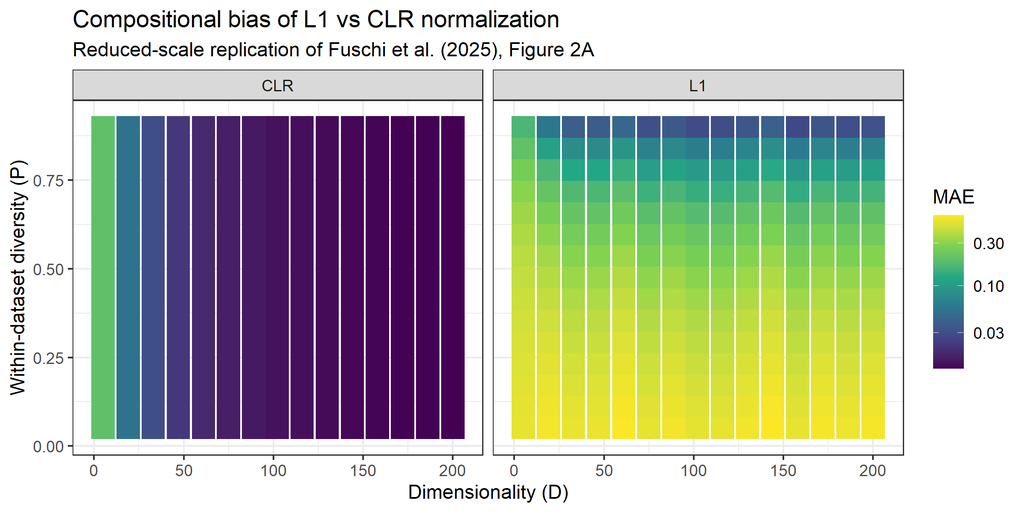

```r
# display the heatmap previously generated by compositional_bias_D_P.R
knitr::include_graphics(
  list.files(
    path = here(),
    pattern = "^compositional_bias_heatmap\\.png$",
    full.names = TRUE,
    recursive = TRUE
  )
)
```

```
#-----------------------------------------------------------------------#
```

### ph_dataset_diversity_confrontation.R

*What it does:* uses `data_sim_ph_driven()` across a pH gradient, at five different levels of pH tolerance, and tracks how the within dataset diversity parameter changes, showing that narrow-tolerance (“specialist”) communities produce noisier, lower evenness, while wide-tolerance (“generalist”) communities stay stable and high.

*Why is it here:* this is the final script presented in this project. `data_sim_ph_driven.R` is, in my humble opinion, a good simulation tool, but a tool with no job to do is just a tool, so it needed to be put to work and see what it could actually produce.  
Rather than reaching for something overly elaborate, I chose to explore a result most people would already expect intuitively: specialist taxa tend to generate environments with lower diversity.

*How it works:* loops over a pH gradient for five tolerance scenarios, computes `pielou_ind()` at each point, plots the five curves, and combines them into a single figure.

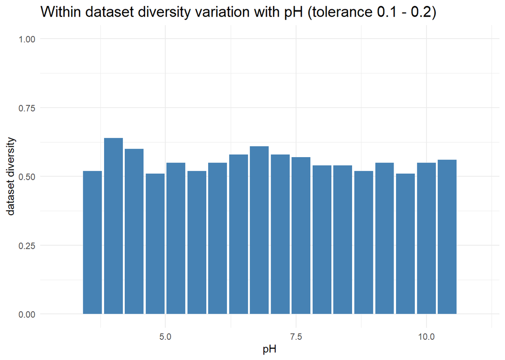

```
#----------------------------------------------------------------------#

pH and within dataset diversity calculated are:
     ph pielou
1   3.6   0.52
2   4.0   0.64
3   4.4   0.60
4   4.8   0.51
5   5.2   0.55
6   5.6   0.52
7   6.0   0.55
8   6.4   0.58
9   6.8   0.61
10  7.2   0.58
11  7.6   0.57
12  8.0   0.54
13  8.4   0.54
14  8.8   0.52
15  9.2   0.55
16  9.6   0.51
17 10.0   0.55
18 10.4   0.56

#----------------------------------------------------------------------#
```

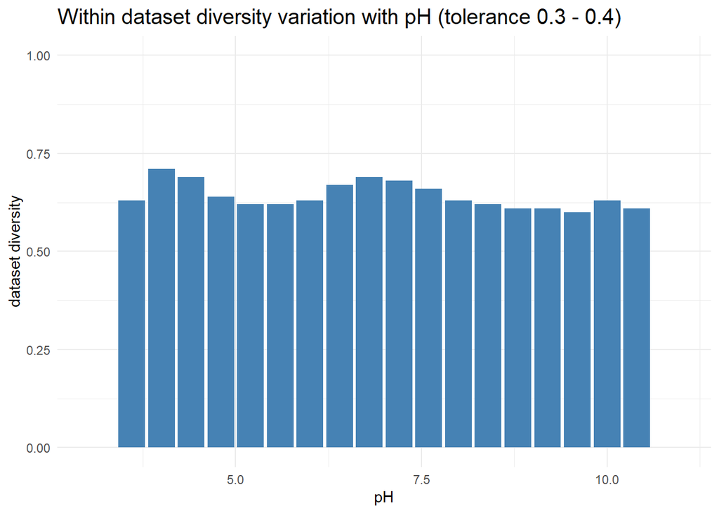

```
#----------------------------------------------------------------------#

pH and dataset diversity calculated are:
     ph pielou_01
1   3.6      0.63
2   4.0      0.71
3   4.4      0.69
4   4.8      0.64
5   5.2      0.62
6   5.6      0.62
7   6.0      0.63
8   6.4      0.67
9   6.8      0.69
10  7.2      0.68
11  7.6      0.66
12  8.0      0.63
13  8.4      0.62
14  8.8      0.61
15  9.2      0.61
16  9.6      0.60
17 10.0      0.63
18 10.4      0.61

#----------------------------------------------------------------------#
```

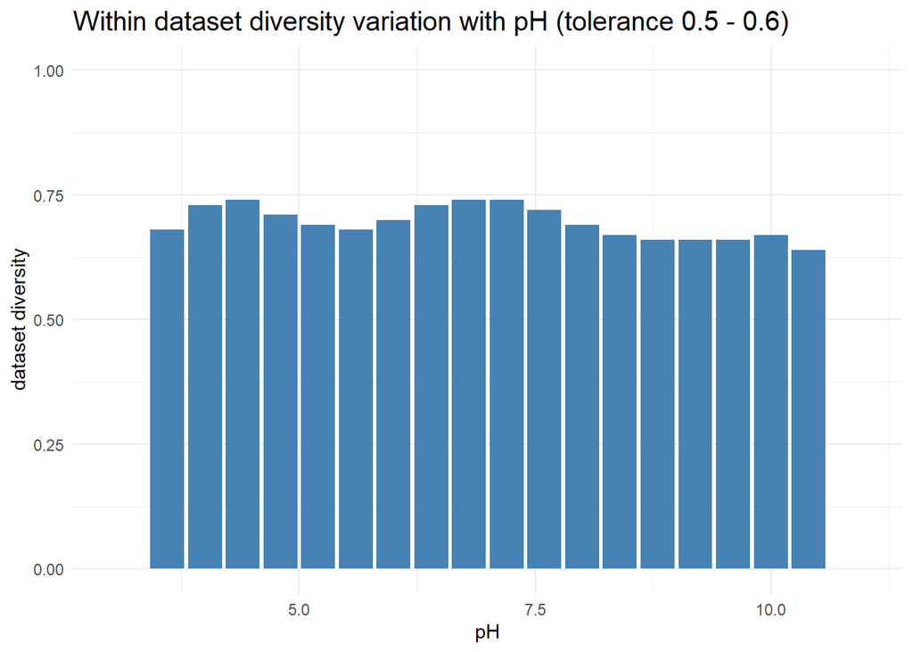

```
#----------------------------------------------------------------------#

pH and dataset diversity calculated are:
     ph pielou_02
1   3.6      0.68
2   4.0      0.73
3   4.4      0.74
4   4.8      0.71
5   5.2      0.69
6   5.6      0.68
7   6.0      0.70
8   6.4      0.73
9   6.8      0.74
10  7.2      0.74
11  7.6      0.72
12  8.0      0.69
13  8.4      0.67
14  8.8      0.66
15  9.2      0.66
16  9.6      0.66
17 10.0      0.67
18 10.4      0.64

#----------------------------------------------------------------------#
```

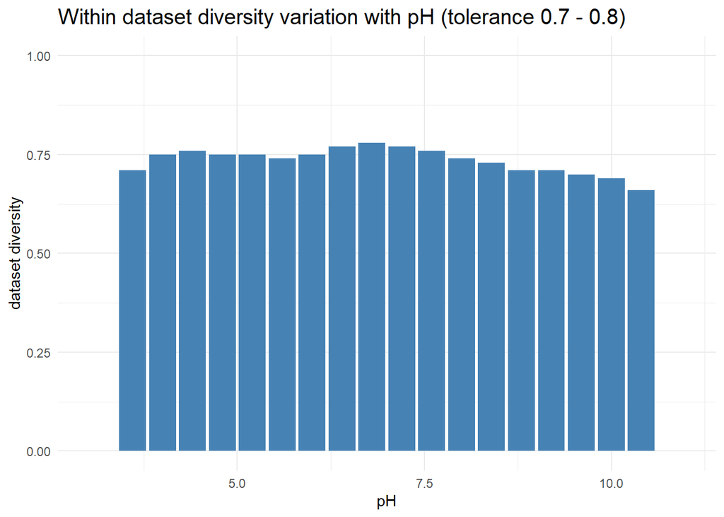

```
#----------------------------------------------------------------------#

pH and dataset diversity calculated are:
     ph pielou_03
1   3.6      0.71
2   4.0      0.75
3   4.4      0.76
4   4.8      0.75
5   5.2      0.75
6   5.6      0.74
7   6.0      0.75
8   6.4      0.77
9   6.8      0.78
10  7.2      0.77
11  7.6      0.76
12  8.0      0.74
13  8.4      0.73
14  8.8      0.71
15  9.2      0.71
16  9.6      0.70
17 10.0      0.69
18 10.4      0.66

#----------------------------------------------------------------------#
```

```
#----------------------------------------------------------------------#

pH and dataset diversity calculated are:
     ph pielou_04
1   3.6      0.74
2   4.0      0.77
3   4.4      0.78
4   4.8      0.79
5   5.2      0.79
6   5.6      0.79
7   6.0      0.79
8   6.4      0.80
9   6.8      0.80
10  7.2      0.80
11  7.6      0.79
12  8.0      0.78
13  8.4      0.77
14  8.8      0.75
15  9.2      0.74
16  9.6      0.73
17 10.0      0.71
18 10.4      0.69

#----------------------------------------------------------------------#
```

[figure not shown]

```
#----------------------------------------------------------------------#
The final plot has been saved in the <Plots> folder
#----------------------------------------------------------------------#
```

```r
# brings the ph_dataset_diversity_confrontation script into scope
source(
  list.files(
    path = here(),
    pattern = "^ph_dataset_diversity_confrontation\\.R$",
    full.names = TRUE,
    recursive = TRUE
  )
)
```

## Project explanation

The previous sections documented each script *in isolation*: what it does, why it exists, and how it works, each with a small, self-contained example. This section instead follows the *actual logical path* of the project, from the initial research question to the final results, showing how the base functions and orchestrators are chained together into the two standalone analyses.  
In short: earlier, we looked at the tools in the toolbox, now we look at why and how we needed those tools.

### Starting point and research question

The project starts from a specific claim made in the original paper (Fuschi et al., 2025): that the CLR transformation, combined with Pearson’s correlation, is a reliable way to estimate taxon-taxon correlations in high-dimensional, compositional metagenomic data, and that this reliability improves with dimensionality (the “blessing of dimensionality”).  
Two questions follow directly from this claim:

1. *How much* compositional bias does CLR actually remove compared to a simpler normalization (L1), and how does this depend on the number of taxa (D) and on how evenly abundances are distributed within a sample (P, within dataset diversity)?
2. Can the sparsity patterns typically simulated to test this kind of method be made more biologically realistic, instead of relying on a single, arbitrary zero-inflation parameter shared by every taxon?

These two questions map directly onto the two standalone analyses of the project.

### Building the tools, in the order they were needed

To answer question 1 (`compositional_bias_D_P.R`), three ingredients were needed first:

- a way to measure within-dataset diversity for any simulated dataset → `pielou_ind()`;
- a way to compute CLR (reused directly inside `compositional_bias_D_P.R`, following the same logic already implemented for real data in `clr_pearson.R`);
- no correlation matrix generator was needed here, since the ground truth for this analysis is deliberately the identity matrix (zero true correlation everywhere), so that any correlation measured after normalization is attributable only to the compositional constraint.

To answer question 2 (`data_sim_ph_driven.R`, used in `ph_dataset_diversity_confrontation.R`), a different chain of tools was needed:

- a way to generate a controlled, valid correlation matrix for the simulated taxa → `generate_matrix_factors()`;
- a way to turn that correlation matrix into a realistic, sparse count dataset → the NorTA approach, first implemented with a single shared zero-inflation parameter in `NorTa_simulation.R`;
- the actual extension of the project: replacing that single shared parameter with a per-taxon, pH-driven zero-inflation probability → `data_sim_ph_driven.R`;
- `pielou_ind()` again, this time to measure how the *pattern* of sparsity (not just its overall amount) affects within-dataset diversity along a pH gradient.

In parallel, on the real-data side of the project, `datasummary.R`, `filt_data.R` and `pseudocount.R` were written to bring a real OTU table into a state where CLR is applicable (no zeroes, low-quality OTUs removed), and `clr_pearson.R` orchestrates them into the same CLR + Pearson pipeline that the simulation-based analyses are meant to stress-test.

### The full pipeline

Putting everything together, the analysis follows this order:

1. **Real-data pipeline** (`clr_pearson.R`, using `datasummary.R`, `filt_data.R`, `pseudocount.R`): a raw OTU table is summarized, filtered, pseudocounted and CLR-transformed, producing an OTU x OTU Pearson correlation matrix. This is the concrete instance of the method whose reliability the original paper discusses, and which the rest of the project investigates more systematically.
2. **Compositional bias analysis** (`compositional_bias_D_P.R`, using `pielou_ind()`): stepping back from any single real dataset, this analysis asks how much bias CLR (and, for comparison, L1) introduces *in general*, as a function of D (dimensionality) and P (within dataset diversity), using fully uncorrelated synthetic data as ground truth.  
   The output (the MAE heatmap) is a direct, quantitative confirmation of the “blessing of dimensionality” claim.
3. **Realistic sparsity simulation** (`generate_matrix_factors.R` → `NorTa_simulation.R` → `data_sim_ph_driven.R`): moving from an arbitrary, single zero-inflation parameter to a per-taxon, ecologically motivated one, this chain produces simulated datasets whose sparsity pattern has a biological interpretation (pH niches), rather than being a free simulation knob.
4. **pH-driven diversity analysis** (`ph_dataset_diversity_confrontation.R`, using `data_sim_ph_driven()` and `pielou_ind()`): the pH-driven simulator is finally used to study how community evenness responds to an environmental gradient, contrasting specialist (narrow pH tolerance) and generalist (wide pH tolerance) taxa.

Steps 1 and 2, and steps 3 and 4, can be run independently of each other: they answer the two separate research questions above, and neither depends on the other’s output. What they share is the same underlying toolkit (`pielou_ind()`, and the CLR logic), which is why both are presented in the same project rather than as two unrelated scripts.

## Conclusions

This notebook walked through the two research questions posed at the start of the “Project explanation” chapter.  
On the compositional bias side, the results confirm what the original paper reports: CLR consistently outperforms L1 at removing spurious correlation, and the gap between the two widens as dimensionality grows, giving the “blessing of dimensionality” that the paper describes.  
On the simulation side, making sparsity pH-driven rather than a single shared parameter produces the expected ecological pattern: specialist taxa generate lower, noisier diversity, while generalist taxa keep it high and stable across the pH gradient.